# Introduction to S7

A new Object Oriented System for R

Cole Brokamp

2024-01-10

## 👋 Welcome

[Join](https://outlook.office365.com/owa/r@cchmc.onmicrosoft.com/groupsubscription.ashx?action=join) the RUG Outlook group for updates and events: https://t.ly/vRw7y

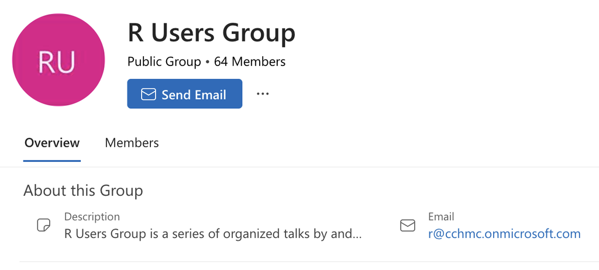

# Introduction to S7

A new Object Oriented System for R

## Intro to Object Oriented Programming (OOP)

### Polymorphism

- consider a function’s interface separately from its implementation
- use the same function form for different types of input

```r
summary(ggplot2::diamonds$carat)
```

```
   Min. 1st Qu.  Median    Mean 3rd Qu.    Max.
 0.2000  0.4000  0.7000  0.7979  1.0400  5.0100
```

```r
summary(ggplot2::diamonds$cut)
```

```
     Fair      Good Very Good   Premium     Ideal
     1610      4906     12082     13791     21551
```

## Why do we need OOP in R?

Most functional programming approaches use base classes and add code within functions to validate inputs based on class

```r
geomark <- function(lat, lon) {
  if (!is.numeric(lat)) {
    stop("lat must be numeric")
  }
  else if (!is.numeric(lon)) {
    stop("lon must be numeric")
  }
  else if (lat < -90 | lat > 90) {
    stop("lat must be between -90 and 90")
  }
  else if (lon < -180 | lon > 180) {
    stop("lon must be between -180 and 180")
  }
  . . .
}
```

1. Handling more types of data causes the function to get bigger and bigger
2. Only the author of the function can add new types

## OOP Terminology

**Generics** define behavior or what an object does  
**Classes** define data or what an object is

- Classes organized in a hierarchy so “fall back” parent method can be tried (**inheritance**)
  - For example, ordered factor in R inherits from a regular factor
- Finding the correct method given a class is called **method dispatch**

## OOP Paradigms

### Encapsulated OOP

- methods belong to objects or classes
- method calls look like: `object.method(arg1, arg2)`
- encapsulates both data (fields) and behavior (methods)
- found in most popular languages

### Functional OOP

- methods belong to generic functions
- method calls look like ordinary function calls: `generic(object, arg2, arg3)`

## Existing OOP in R

**S3**: first, informal implementation that relies on common conventions

**S4**: rigorous rewrite of S3 and provides greater encapsulation

**RC**: implements encapsulated OOP as a special type of S4 objects that are mutable

**R6**, **R.oo**, **proto** are other popular systems implemented in CRAN packages

## Exploring OOP in R

```r
library(sloop)
```

```r
otype(1:10)
```

```
[1] "base"
```

```r
otype(mtcars)
```

```
[1] "S3"
```

```r
mle_obj <- stats4::mle(function(x = 1) (x - 2) ^ 2)
otype(mle_obj)
```

```
[1] "S4"
```

## S3 in R

An S3 object is a base type with at least a `class` attribute:

```r
f <- factor(c("a", "b", "c"))
typeof(f)
```

```
[1] "integer"
```

```r
attributes(f)
```

```
$levels
[1] "a" "b" "c"

$class
[1] "factor"
```

```r
inherits(f, "factor")
```

```
[1] TRUE
```

```r
s3_dispatch(print(f))
```

```
=> print.factor
 * print.default
```

## S7 is the sucessor to S3 and S4 (and RC)

[figure not shown]

https://xkcd.com/927

- Community adoption, planning, development (R-core, Bioconductor, ROpenSci, Posit, others)
- Design, specification, meeting minutes available at https://rconsortium.github.io/S7/articles/index.html

### Captures the best parts of S4

- Formal definition of classes
- @ helper (that errors) to extract properties
- Multi-dispatch where needed
- Validator

### While remaining 100% backward compatible with S3

- Goal to merge into base R
- Embrace data access
- Digging a “pit of success”

# Using S7 in R

```r
library(S7)
```

## Using S7 in R

Create a constructor function with the name of the class, property names and types:

```r
range <-
  new_class(
    "range",
    properties = list(
      start = class_numeric,
      end = class_numeric
    )
  )
```

```r
x <- range(start = 1, end = 10)
x
```

```
<range>
 @ start: num 1
 @ end  : num 10
```

```r
x@start
```

```
[1] 1
```

```r
x@end <- 20
x
```

```
<range>
 @ start: num 1
 @ end  : num 20
```

```r
x@end <- "x"
```

```
Error: <range>@end must be <integer> or <double>, not <character>
```

## Use validators to prevent “wrong” objects from being created

```r
range(start = 10, end = 1)
```

```
<range>
 @ start: num 10
 @ end  : num 1
```

```r
range <-
  new_class("range",
    properties = list(
      start = class_numeric,
      end = class_numeric
    ),
    validator = function(self) {
      if (length(self@start) != 1) {
        "@start must be length 1"
      } else if (length(self@end) != 1) {
        "@end must be length 1"
      } else if (self@end < self@start) {
        "@end must be greater than or equal to @start"
      }
    })
```

## Create new generic methods for the new class

```r
inside <- new_generic("inside", "x")

method(inside, range) <- function(x, y) {
  y >= x@start & y <= x@end
}

inside(x, c(0, 5, 10))
```

```
[1] FALSE  TRUE  TRUE
```

# Address example

## Address Character Strings

Addresses often stored as combined strings or can be concatenated from other address components (e.g., “address line 1” and “address line 2”)

```r
my_address <- "3333 Burnet ave cincinnati OH 45219"
```

Cleaning and tagging the address extracts components using open natural language processing models:

```r
parcel::tag_address(my_address)
```

```
# A tibble: 1 × 5
  street_number street_name city       state zip_code
  <chr>         <chr>       <chr>      <chr> <chr>
1 3333          burnet ave  cincinnati oh    45219
```

```r
parcel::tag_address("3333 Burnet Ave cincinnati oh 45219-2843")
```

```
# A tibble: 1 × 5
  street_number street_name city       state zip_code
  <chr>         <chr>       <chr>      <chr> <chr>
1 3333          burnet ave  cincinnati oh    45219
```

## Apply to all addresses in a tibble

```r
d <-
  tibble::tibble(id = 1:3,
                 address = rep(my_address, times = 3)) |>
  dplyr::mutate(parsed_address = purrr::map(address, parcel::tag_address))
```

```r
d
```

```
# A tibble: 3 × 3
     id address                             parsed_address
  <int> <chr>                               <list>
1     1 3333 Burnet ave cincinnati OH 45219 <tibble [1 × 5]>
2     2 3333 Burnet ave cincinnati OH 45219 <tibble [1 × 5]>
3     3 3333 Burnet ave cincinnati OH 45219 <tibble [1 × 5]>
```

```r
str(d$parsed_address[[1]])
```

```
tibble [1 × 5] (S3: tbl_df/tbl/data.frame)
 $ street_number: chr "3333"
 $ street_name  : chr "burnet ave"
 $ city         : chr "cincinnati"
 $ state        : chr "oh"
 $ zip_code     : chr "45219"
```

## Challenge

With a tibble full of addresses, how can we maintain tidy data with a character string returning a tibble with five columns?

```r
tidyr::unnest(d, cols = parsed_address)
```

```
# A tibble: 3 × 7
     id address                   street_number street_name city  state zip_code
  <int> <chr>                     <chr>         <chr>       <chr> <chr> <chr>
1     1 3333 Burnet ave cincinna… 3333          burnet ave  cinc… oh    45219
2     2 3333 Burnet ave cincinna… 3333          burnet ave  cinc… oh    45219
3     3 3333 Burnet ave cincinna… 3333          burnet ave  cinc… oh    45219
```

A common challenge faced by {sf}, {dplyr} or any other package that utilizes classes of vectors designed to be used in a data.frame.

**Approach**

Use S7 package to create a new class for addresses that will interoperate with existing R objects and packages.

Create an address class that will have properties for each address component, but use the `print` generic to neatly print the full string instead of each component as a list.

## Define a New Class with S7

```r
library(S7)

addr <- new_class(
  "addr",
  parent = class_character,
  properties = list(
    street_number = class_numeric,
    street_name = class_character,
    city = class_character,
    state = class_character,
    zip_code = class_character
  ),
  validator = function(self) {
    if (any(nchar(self@zip_code) != 5)) {
      "@zip_code must contain five characters"
    }
  }
)
```

## Creating a new `addr` object

```r
addr("3333 Burnet Ave Cincinnati OH 45219",
     street_number = 3333,
     street_name = "Burnet Ave",
     city = "Cincinnati",
     state = "OH",
     zip_code = "45219")
```

```
<addr> chr "3333 Burnet Ave Cincinnati OH 45219"
 @ street_number: num 3333
 @ street_name  : chr "Burnet Ave"
 @ city         : chr "Cincinnati"
 @ state        : chr "OH"
 @ zip_code     : chr "45219"
```

## Helpful validation

This comes with validation for classes of arguments:

```r
addr("3333 Burnet Ave Cincinnati OH 45219",
     street_number = "3333",
     street_name = "Burnet Ave",
     city = "Cincinnati",
     state = "OH",
     zip_code = "45219")
```

```
Error: <addr> object properties are invalid:
- @street_number must be <integer> or <double>, not <character>
```

and for anything defined in the validator:

```r
addr("3333 Burnet Ave Cincinnati OH 45219",
     street_number = 3333,
     street_name = "Burnet Ave",
     city = "Cincinnati",
     state = "OH",
     zip_code = "45219-2234")
```

```
Error: <addr> object is invalid:
- @zip_code must contain five characters
```

## New objects are tedious; more common to coerce objects

```r
my_address
```

```
[1] "3333 Burnet ave cincinnati OH 45219"
```

```r
as_addr <- function(x) {
  x_tags <-
    parcel::tag_address(x) |>
    as.list()
  x_tags$street_number <- as.numeric(x_tags$street_number)
  return(do.call(addr, c(x, x_tags)))
}
```

```r
as_addr(my_address)
```

```
<addr> chr "3333 Burnet ave cincinnati OH 45219"
 @ street_number: num 3333
 @ street_name  : chr "burnet ave"
 @ city         : chr "cincinnati"
 @ state        : chr "oh"
 @ zip_code     : chr "45219"
```

## Create a custom print method

```r
S7::method(print, addr) <- function(x, ...) {
  glue::glue_data(props(x),
                  "{street_number} ",
                  "{stringr::str_to_title(street_name)} ",
                  "{stringr::str_to_title(city)}, {toupper(state)} ",
                  "{zip_code}") |>
    cat()
  cat("\n")
}

as_addr(my_address)
```

```
3333 Burnet Ave Cincinnati, OH 45219
```

```r
str(as_addr(my_address))
```

```
<addr> chr "3333 Burnet ave cincinnati OH 45219"
 @ street_number: num 3333
 @ street_name  : chr "burnet ave"
 @ city         : chr "cincinnati"
 @ state        : chr "oh"
 @ zip_code     : chr "45219"
```

## Print works inside tibbles

```r
my_addresses <-
  c("224 Woolper Ave Cincinnati OH 45220",
    "3333 Burnet Ave Cincinnati OH 45219")

d <-
  tibble::tibble(
  id = 1:2,
  address = purrr::map(my_addresses, as_addr)
  )

d
```

```
# A tibble: 2 × 2
     id address
  <int> <list>
1     1 <addr [1]>
2     2 <addr [1]>
```

```r
d$address
```

```
[[1]]
224 Woolper Ave Cincinnati, OH 45220

[[2]]
3333 Burnet Ave Cincinnati, OH 45219
```

## Extract properties to get at individual address components

```r
d$zip_code <- purrr::map_chr(d$address, prop, "zip_code")

d
```

```
# A tibble: 2 × 3
     id address    zip_code
  <int> <list>     <chr>
1     1 <addr [1]> 45220
2     2 <addr [1]> 45219
```

## Related work and more resources

- https://rconsortium.github.io/S7/index.html
- https://adv-r.hadley.nz/oo.html
- [vctrs](https://vctrs.r-lib.org/) package for a more stable way to create new S3 vectors
- [Intro to S7 talk at posit::conf(2022)](https://www.youtube.com/watch?v=P3FxCvSueag)
- Applied example in fr package: https://cran.r-project.org/package=fr

# Thank You

👨‍💻️ github.com/cole-brokamp

𝕏 [@cole_brokamp](https://twitter.com/cole_brokamp)

📧 cole.brokamp@cchmc.org